# Midterm Notebook

Michael Schmidlin 4/6/23

In this notebook we will attempt to predict stock prices by using different types of RNN (Recurrent Neural Network). RNN's are most commonly used for NLP (Natural Language Processing) and other types of sequence related tasks. This makes them ideal for time series predictions.

Specifically for this task, we will attempt to predict stock price (closing price) only using historical stock price data. This means that we are relying solely in the algorithm to find patterns in the historical stock data.

In this notebook we will use regular RNN but also GRU and LSTM which are more advanced and also very popular kinds of RNN. We will be using Pytorch to implement the models.

The stock data will be retrieved through the use of Alpaca API. Alpaca, is an online brokerage that has stock data and free paper trading accounts with a full python library.

## Import Necessary Libraries

`Market_Monitor` and `Stock_Trader` are both custom wrappers for Alpaca functionality that were developed for this project.

In addition `torch_utils` is a custom file with functions and models pre-defined in order to keep the notebook clean.

Becuase of these custom modules, `%load_ext autoreload` is almost required becuase it makes development much eaiser.

```python
%load_ext autoreload
%autoreload 2
```

```python
import time
from configs import TIMEZONE, LOG_FILE_NAME, set_logger
from datetime import datetime, timedelta
import pytz
import matplotlib.pyplot as plt
import pandas as pd
import numpy as np
import seaborn as sns
from sklearn.preprocessing import MinMaxScaler, StandardScaler
from alpaca.trading.client import TradingClient
from alpaca.trading.requests import MarketOrderRequest
from alpaca.trading.enums import OrderSide, TimeInForce
from alpaca.trading.requests import GetAssetsRequest
from alpaca.data.historical import StockHistoricalDataClient, CryptoHistoricalDataClient
from alpaca.data.requests import StockLatestQuoteRequest, StockBarsRequest, CryptoLatestQuoteRequest
from alpaca.data.requests import CryptoBarsRequest
from alpaca.trading.models import Order
from alpaca.data.timeframe import TimeFrame
from my_secrets import ALPACA_API_BASE_URL, PAPER_API_ID, PAPER_SECRET_KEY
import logging
import plotly.express as px
import plotly.graph_objects as go
set_logger()
```

```python
import torch
import torch.nn as nn
```

```python
from Trade_Class import Stock_Trader, Crypto_Trader
from Market_Monitor import Market_Monitor
```

```python
from torch_utils import *
```

## Get Market Data

We will use our Alpaca wrapper classes to get the stock data. We will start by using Apple stock data and fetching every day from 2015 to 2023.

```python
stock_trader = Stock_Trader(PAPER_API_ID, PAPER_SECRET_KEY, paper=True)
monitor = Market_Monitor(stock_trader.trading_client, TIMEZONE)
```

```python
start = datetime(year=2015, month=1, day=1, hour=0, minute=0, second=0)
end = datetime(year=2023, month=2, day=1, hour=0, minute=0, second=0)
bars_df = stock_trader.get_bars('AAPL', start=start, end=end, time_resolution='day')
bars_df.reset_index(inplace=True)
bars_df.sort_values(by=['timestamp'], ascending=True, inplace=True)
print(bars_df.shape)
display(bars_df.head())
```

```
(1804, 9)
```

|  | symbol | timestamp | open | high | low | close | volume | trade_count | vwap |
| --- | --- | --- | --- | --- | --- | --- | --- | --- | --- |
| 0 | AAPL | 2015-12-01 05:00:00+00:00 | 118.75 | 118.81 | 116.86 | 117.34 | 34852374.0 | 187129.0 | 117.756760 |
| 1 | AAPL | 2015-12-02 05:00:00+00:00 | 117.05 | 118.11 | 116.08 | 116.28 | 33385643.0 | 180616.0 | 117.151198 |
| 2 | AAPL | 2015-12-03 05:00:00+00:00 | 116.55 | 116.79 | 114.22 | 115.20 | 41560785.0 | 245330.0 | 115.434888 |
| 3 | AAPL | 2015-12-04 05:00:00+00:00 | 115.29 | 119.25 | 115.11 | 119.03 | 57776977.0 | 307788.0 | 118.187290 |
| 4 | AAPL | 2015-12-07 05:00:00+00:00 | 118.98 | 119.86 | 117.81 | 118.28 | 32080754.0 | 190809.0 | 118.509111 |

Short descriptions:

- symbol: stock symbol
- timestamp: datetime information
- open: Open price of a stock on a particular day
- high: Highest price of a stock on a particular day
- low: lowest price of a stock on a particular day
- close: last price of a stock on a particular day
- volume: how many shares were traded on a particular day
- trade_count: how many trades were made on a particular day
- vwap: volume-weighted-price-average

## Define Hyperparameters

We define our hypter parameters at the top of the notebook to make the logistics of model tuning easier. `DEVICE` is coded such that there will be no issues if you run on a computer with no NVIDIA GPU.

```python
SEQUENCE_LENGTH = 50 #the sequence length we will use for prediction
NUM_LAYERS = 2 #the number of layers to use in our RNN type models
HIDDEN_SIZE = 64 #the hidden size of our models
DEVICE = 'cuda' if torch.cuda.is_available() else 'cpu'
TEST_PCT = 0.25 #what percentage of our data to use for testing
BATCH_SIZE = 32 #batch size to use for training. Can make this smaller or bigger depending on comptuer hardware
EPOCHS = 100 #Number of epochs to train for
PRED_IDX = 0 # the index in the data to predict. This parameter will make more sense later when we use more features to try and predict closing price.
```

## Create Dataset

Okay let's get into creating our dataset. First, we take our dataframe and just take the 'close' column. Then we turn it into a train array and a test array using our `TEST_PCT`. This is all done for us inside `prep_RNN_data`.

Then we take our train and test arrays and pass them into the `RNNDataset` constructor. `RNNDataset` is a custom dataclass inheriting from pytorch's own dataclass. This makes it easy and clean for the the next step.

The next step being to create pytorch DataLoaders from our datasets. In addition to the regular DataLoader we will wrap the DataLoader with our own custom `DeviceDataLoader`. This will automatically load our training and testing batches to our agnostic device.

Finall we check the shape of our first batch of data and we see that it is (`BATCH_SIZE`, `SEQUENCE_LENGTH`, num_features). Since we are just using 'close' price right now our number of featrues is 1.

```python
train_array, test_array = prep_RNN_data(bars_df, cols=['close'], test_pct=TEST_PCT, scaler=MinMaxScaler())
train_array.shape, test_array.shape
```

```
((1353, 1), (451, 1))
```

```python
train_dataset = RNNDataset(train_array, SEQUENCE_LENGTH,)
test_dataset = RNNDataset(test_array, SEQUENCE_LENGTH,)

len(train_dataset), len(test_dataset)
```

```
(1302, 400)
```

```python
x_train, y_train = train_dataset[0]
x_train.shape, y_train.shape
```

```
(torch.Size([50, 1]), torch.Size([1]))
```

```python
train_loader = torch.utils.data.DataLoader(train_dataset, BATCH_SIZE, drop_last=True, shuffle=True)
train_loader = DeviceDataLoader(train_loader, DEVICE)
test_loader = torch.utils.data.DataLoader(test_dataset, BATCH_SIZE, drop_last=True)
test_loader = DeviceDataLoader(test_loader, DEVICE)
```

```python
trainer_iter = iter(train_loader)
x_train, y_train = next(trainer_iter)
x_train.shape, y_train.shape
```

```
(torch.Size([32, 50, 1]), torch.Size([32, 1]))
```

## Create Models

Here we get to the fun part. We will create our three models using custom classes housed in `torch_utils`. Since all three models work in a similar way, they also have similar hyperparemeters.

Becuase pytorch links optimizers to the model parameters in the background, we will need three different optimizers. However we only need one loss function. We will use MSE (Mean Squared Error) loss since it is a common standard for regression tasks.

```python
rnn_model = RNN(input_dim=1, hidden_dim=HIDDEN_SIZE, output_dim=1, num_layers=NUM_LAYERS)
rnn_model.to(DEVICE)
lstm_model = LSTM(input_dim=1, hidden_dim=HIDDEN_SIZE, output_dim=1, num_layers=NUM_LAYERS)
lstm_model.to(DEVICE)
gru_model = GRU(input_dim=1, hidden_dim=HIDDEN_SIZE, output_dim=1, num_layers=NUM_LAYERS)
gru_model.to(DEVICE)

loss_fn = torch.nn.MSELoss()

rnn_optimizer = torch.optim.Adam(rnn_model.parameters(), lr=0.001)
lstm_optimizer = torch.optim.Adam(lstm_model.parameters(), lr=0.001)
gru_optimizer = torch.optim.Adam(gru_model.parameters(), lr=0.001)
```

## Train Models

Our model training will be wrapped in `fit_model`. `fit_model` goes through a standard pytorch training loop and records losses so that we can analyze them. It also print out the losses every `print_divider=10` epochs so we can see real time how it's learning.

```python
rnn_training_losses, rnn_testing_losses = fit_model(EPOCHS, rnn_model, train_loader, test_loader, loss_fn, rnn_optimizer)
```

```
Epoch 0  	Train MSE: 0.01414	Test MSE: 0.00014
Epoch 10  	Train MSE: 0.00096	Test MSE: 0.00009
Epoch 20  	Train MSE: 0.00087	Test MSE: 0.00008
Epoch 30  	Train MSE: 0.00083	Test MSE: 0.00010
Epoch 40  	Train MSE: 0.00095	Test MSE: 0.00014
Epoch 50  	Train MSE: 0.00071	Test MSE: 0.00017
Epoch 60  	Train MSE: 0.00075	Test MSE: 0.00027
Epoch 70  	Train MSE: 0.00090	Test MSE: 0.00012
Epoch 80  	Train MSE: 0.00078	Test MSE: 0.00010
Epoch 90  	Train MSE: 0.00090	Test MSE: 0.00008
```

```python
lstm_training_losses, lstm_testing_losses = fit_model(EPOCHS, lstm_model, train_loader, test_loader, loss_fn, lstm_optimizer)
```

```
Epoch 0  	Train MSE: 0.03011	Test MSE: 0.00619
Epoch 10  	Train MSE: 0.00154	Test MSE: 0.00015
Epoch 20  	Train MSE: 0.00100	Test MSE: 0.00016
Epoch 30  	Train MSE: 0.00089	Test MSE: 0.00030
Epoch 40  	Train MSE: 0.00076	Test MSE: 0.00027
Epoch 50  	Train MSE: 0.00067	Test MSE: 0.00012
Epoch 60  	Train MSE: 0.00073	Test MSE: 0.00008
Epoch 70  	Train MSE: 0.00084	Test MSE: 0.00008
Epoch 80  	Train MSE: 0.00070	Test MSE: 0.00010
Epoch 90  	Train MSE: 0.00064	Test MSE: 0.00015
```

```python
gru_training_losses, gru_testing_losses = fit_model(EPOCHS, gru_model, train_loader, test_loader, loss_fn, gru_optimizer)
```

```
Epoch 0  	Train MSE: 0.03283	Test MSE: 0.00852
Epoch 10  	Train MSE: 0.00096	Test MSE: 0.00008
Epoch 20  	Train MSE: 0.00083	Test MSE: 0.00009
Epoch 30  	Train MSE: 0.00087	Test MSE: 0.00006
Epoch 40  	Train MSE: 0.00086	Test MSE: 0.00009
Epoch 50  	Train MSE: 0.00074	Test MSE: 0.00009
Epoch 60  	Train MSE: 0.00078	Test MSE: 0.00016
Epoch 70  	Train MSE: 0.00076	Test MSE: 0.00043
Epoch 80  	Train MSE: 0.00073	Test MSE: 0.00012
Epoch 90  	Train MSE: 0.00082	Test MSE: 0.00006
```

## Visualizations

### MSE Loss

[figure not shown]

```python
plot_losses(EPOCHS, rnn_training_losses, rnn_testing_losses, title_addition='RNN Model')
```

[figure not shown]

```python
plot_losses(EPOCHS, lstm_training_losses, lstm_testing_losses, title_addition='LSTM Model')
```

[figure not shown]

```python
plot_losses(EPOCHS, gru_training_losses, gru_testing_losses, title_addition='GRU Model')
```

### Predicted Closing Prices

In addition to predicted closing prices, you can see that we have also measured the "accuracy" of the model. More on this later.

```python
historical_array = train_array[:, PRED_IDX]
historical_array.shape # get the closing prices of all the training data for context
```

```
(1353,)
```

```
              precision    recall  f1-score   support

           0       0.33      0.04      0.07       195
           1       0.50      0.92      0.65       204

    accuracy                           0.49       399
   macro avg       0.42      0.48      0.36       399
weighted avg       0.42      0.49      0.37       399
```

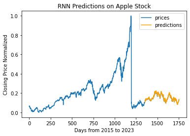

```python
visualize_predictions(rnn_model, historical_array, test_dataset, DEVICE, title='RNN Predictions on Apple Stock')
```

```
              precision    recall  f1-score   support

           0       0.00      0.00      0.00       195
           1       0.51      1.00      0.67       204

    accuracy                           0.51       399
   macro avg       0.26      0.50      0.34       399
weighted avg       0.26      0.51      0.34       399
```

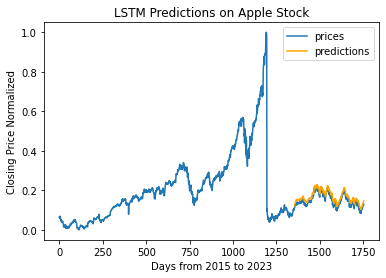

```python
visualize_predictions(lstm_model, historical_array, test_dataset, DEVICE, title='LSTM Predictions on Apple Stock')
```

```
              precision    recall  f1-score   support

           0       0.47      0.69      0.56       195
           1       0.47      0.27      0.34       204

    accuracy                           0.47       399
   macro avg       0.47      0.48      0.45       399
weighted avg       0.47      0.47      0.45       399
```

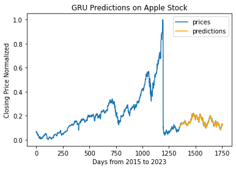

```python
visualize_predictions(gru_model, historical_array, test_dataset, DEVICE, title='GRU Predictions on Apple Stock')
```

### Chained Closing Prices

"Chained" Closing prices is essentially, rather than using the previous `SEQUENCE_LENGTH` of actual stock data, you use the previous `SEQUENCE_LENGTH` of *predictions*. Of course if your predictions don't go back as far as `SEQUENCE_LENGTH` then the beginning part of your predictor data is filled in with actual stock data. By doing this, we are sort of asking "how far in the future can we accurately predict?".

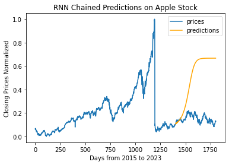

```python
visualize_chained_predictions(rnn_model, train_array, test_array, DEVICE, title='RNN Chained Predictions on Apple Stock')
```

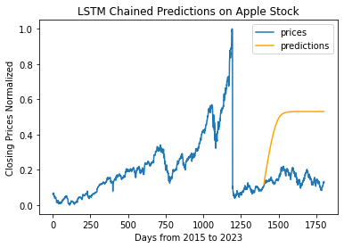

```python
visualize_chained_predictions(lstm_model, train_array, test_array, DEVICE, title='LSTM Chained Predictions on Apple Stock')
```

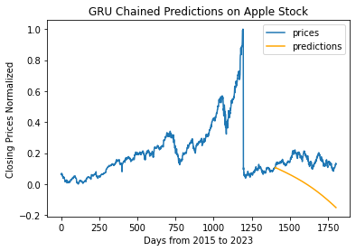

```python
visualize_chained_predictions(gru_model, train_array, test_array, DEVICE, title='GRU Chained Predictions on Apple Stock')
```

## Hypter Parameter Tuning

We use the term hypterparameter tuning loosely here. What we will actually be changing is:

### Increase Input Feature Space

Now, instead of using just 'close' price to try and predict 'close' price. We will instead use five features: 'open', 'high', 'low', 'close', and 'volume'. The intent here is that hopefully the model will be able to predict better (or at all) what the next day stock price will be.

```python
PRED_IDX = 3 #set this since we are trying to predict 'close' price
```

```python
train_array, test_array = prep_RNN_data(bars_df, cols=['open', 'high', 'low', 'close', 'volume'],
                                        test_pct=TEST_PCT, scaler=MinMaxScaler())
train_array.shape, test_array.shape
```

```
((1353, 5), (451, 5))
```

```python
train_dataset = RNNDataset(train_array, SEQUENCE_LENGTH, pred_idx=PRED_IDX)
test_dataset = RNNDataset(test_array, SEQUENCE_LENGTH, pred_idx=PRED_IDX)

len(train_dataset), len(test_dataset)
```

```
(1302, 400)
```

```python
x_train, y_train = train_dataset[0]
x_train.shape, y_train.shape
```

```
(torch.Size([50, 5]), torch.Size([1]))
```

```python
train_loader = torch.utils.data.DataLoader(train_dataset, BATCH_SIZE, drop_last=True, shuffle=True)
train_loader = DeviceDataLoader(train_loader, DEVICE)
test_loader = torch.utils.data.DataLoader(test_dataset, BATCH_SIZE, drop_last=True)
test_loader = DeviceDataLoader(test_loader, DEVICE)
```

```python
trainer_iter = iter(train_loader)
x_train, y_train = next(trainer_iter)
x_train.shape, y_train.shape
```

```
(torch.Size([32, 50, 5]), torch.Size([32, 1]))
```

```python
rnn_model = RNN(input_dim=5, hidden_dim=HIDDEN_SIZE, output_dim=1, num_layers=NUM_LAYERS)
rnn_model.to(DEVICE)
lstm_model = RNN(input_dim=5, hidden_dim=HIDDEN_SIZE, output_dim=1, num_layers=NUM_LAYERS)
lstm_model.to(DEVICE)
gru_model = GRU(input_dim=5, hidden_dim=HIDDEN_SIZE, output_dim=1, num_layers=NUM_LAYERS)
gru_model.to(DEVICE)

loss_fn = torch.nn.MSELoss()

rnn_optimizer = torch.optim.Adam(rnn_model.parameters(), lr=0.001)
lstm_optimizer = torch.optim.Adam(lstm_model.parameters(), lr=0.001)
gru_optimizer = torch.optim.Adam(gru_model.parameters(), lr=0.001)
```

```python
rnn_training_losses, rnn_testing_losses = fit_model(EPOCHS, rnn_model, train_loader, test_loader, loss_fn, rnn_optimizer)
```

```
Epoch 0  	Train MSE: 0.00983	Test MSE: 0.00012
Epoch 10  	Train MSE: 0.00088	Test MSE: 0.00012
Epoch 20  	Train MSE: 0.00087	Test MSE: 0.00063
Epoch 30  	Train MSE: 0.00086	Test MSE: 0.00010
Epoch 40  	Train MSE: 0.00105	Test MSE: 0.00012
Epoch 50  	Train MSE: 0.00079	Test MSE: 0.00010
Epoch 60  	Train MSE: 0.00080	Test MSE: 0.00008
Epoch 70  	Train MSE: 0.00095	Test MSE: 0.00054
Epoch 80  	Train MSE: 0.00081	Test MSE: 0.00009
Epoch 90  	Train MSE: 0.00090	Test MSE: 0.00021
```

```python
lstm_training_losses, lstm_testing_losses = fit_model(EPOCHS, lstm_model, train_loader, test_loader, loss_fn, lstm_optimizer)
```

```
Epoch 0  	Train MSE: 0.01136	Test MSE: 0.00013
Epoch 10  	Train MSE: 0.00088	Test MSE: 0.00011
Epoch 20  	Train MSE: 0.00092	Test MSE: 0.00009
Epoch 30  	Train MSE: 0.00090	Test MSE: 0.00011
Epoch 40  	Train MSE: 0.00088	Test MSE: 0.00020
Epoch 50  	Train MSE: 0.00087	Test MSE: 0.00014
Epoch 60  	Train MSE: 0.00091	Test MSE: 0.00008
Epoch 70  	Train MSE: 0.00084	Test MSE: 0.00015
Epoch 80  	Train MSE: 0.00083	Test MSE: 0.00009
Epoch 90  	Train MSE: 0.00077	Test MSE: 0.00012
```

```python
gru_training_losses, gru_testing_losses = fit_model(EPOCHS, gru_model, train_loader, test_loader, loss_fn, gru_optimizer)
```

```
Epoch 0  	Train MSE: 0.01200	Test MSE: 0.00027
Epoch 10  	Train MSE: 0.00091	Test MSE: 0.00010
Epoch 20  	Train MSE: 0.00097	Test MSE: 0.00017
Epoch 30  	Train MSE: 0.00088	Test MSE: 0.00009
Epoch 40  	Train MSE: 0.00085	Test MSE: 0.00032
Epoch 50  	Train MSE: 0.00079	Test MSE: 0.00011
Epoch 60  	Train MSE: 0.00083	Test MSE: 0.00008
Epoch 70  	Train MSE: 0.00075	Test MSE: 0.00013
Epoch 80  	Train MSE: 0.00088	Test MSE: 0.00009
Epoch 90  	Train MSE: 0.00076	Test MSE: 0.00007
```

[figure not shown]

```python
plot_losses(EPOCHS, rnn_training_losses, rnn_testing_losses, title_addition='RNN Model')
```

[figure not shown]

```python
plot_losses(EPOCHS, lstm_training_losses, lstm_testing_losses, title_addition='LSTM Model')
```

[figure not shown]

```python
plot_losses(EPOCHS, gru_training_losses, gru_testing_losses, title_addition='GRU Model')
```

```python
historical_array = train_array[:, PRED_IDX]
historical_array.shape
```

```
(1353,)
```

```
              precision    recall  f1-score   support

           0       0.34      0.06      0.10       195
           1       0.50      0.89      0.64       204

    accuracy                           0.48       399
   macro avg       0.42      0.47      0.37       399
weighted avg       0.42      0.48      0.38       399
```

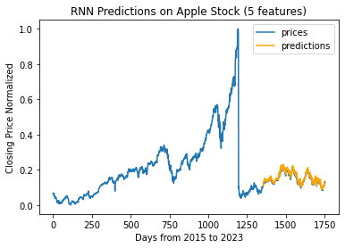

```python
visualize_predictions(rnn_model, historical_array, test_dataset, DEVICE, title='RNN Predictions on Apple Stock (5 features)')
```

```
              precision    recall  f1-score   support

           0       0.46      0.24      0.31       195
           1       0.50      0.74      0.60       204

    accuracy                           0.49       399
   macro avg       0.48      0.49      0.46       399
weighted avg       0.48      0.49      0.46       399
```

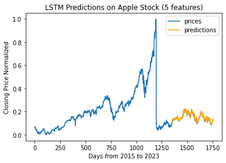

```python
visualize_predictions(lstm_model, historical_array, test_dataset, DEVICE, title='LSTM Predictions on Apple Stock (5 features)')
```

```
              precision    recall  f1-score   support

           0       0.51      0.43      0.46       195
           1       0.53      0.61      0.56       204

    accuracy                           0.52       399
   macro avg       0.52      0.52      0.51       399
weighted avg       0.52      0.52      0.51       399
```

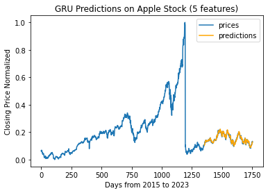

```python
visualize_predictions(gru_model, historical_array, test_dataset, DEVICE, title='GRU Predictions on Apple Stock (5 features)')
```

We won't use the chained prediciton for the 5 features since it doesn't make sense for a model that predicts one feature using 5. It's simply not possible to chain predictions like we did before.

### Increase Layers

Next, we will try increasing the number of layers. Since increasing features didn't help we will go back to a single feature. Thus, this won't be a true grid search but we will be individually trying different hypterparameters.

We will try setting `NUM_LAYERS` as 6 and hope that this increase in model complexity helps the models performance.

We will also discontinue plotting the loss functions this time since it wasn't very informative before.

```python
NUM_LAYERS = 6
PRED_IDX = 0
```

```python
train_array, test_array = prep_RNN_data(bars_df, cols=['close'], test_pct=TEST_PCT, scaler=MinMaxScaler())
display(train_array.shape, test_array.shape)
train_dataset = RNNDataset(train_array, SEQUENCE_LENGTH,)
test_dataset = RNNDataset(test_array, SEQUENCE_LENGTH,)

display(len(train_dataset), len(test_dataset))
train_loader = torch.utils.data.DataLoader(train_dataset, BATCH_SIZE, drop_last=True, shuffle=True)
train_loader = DeviceDataLoader(train_loader, DEVICE)
test_loader = torch.utils.data.DataLoader(test_dataset, BATCH_SIZE, drop_last=True)
test_loader = DeviceDataLoader(test_loader, DEVICE)
rnn_model = RNN(input_dim=1, hidden_dim=HIDDEN_SIZE, output_dim=1, num_layers=NUM_LAYERS)
rnn_model.to(DEVICE)
lstm_model = LSTM(input_dim=1, hidden_dim=HIDDEN_SIZE, output_dim=1, num_layers=NUM_LAYERS)
lstm_model.to(DEVICE)
gru_model = GRU(input_dim=1, hidden_dim=HIDDEN_SIZE, output_dim=1, num_layers=NUM_LAYERS)
gru_model.to(DEVICE)

loss_fn = torch.nn.MSELoss()

rnn_optimizer = torch.optim.Adam(rnn_model.parameters(), lr=0.001)
lstm_optimizer = torch.optim.Adam(lstm_model.parameters(), lr=0.001)
gru_optimizer = torch.optim.Adam(gru_model.parameters(), lr=0.001)
rnn_training_losses, rnn_testing_losses = fit_model(EPOCHS, rnn_model, train_loader, test_loader, loss_fn, rnn_optimizer)
lstm_training_losses, lstm_testing_losses = fit_model(EPOCHS, lstm_model, train_loader, test_loader, loss_fn, lstm_optimizer)
gru_training_losses, gru_testing_losses = fit_model(EPOCHS, gru_model, train_loader, test_loader, loss_fn, gru_optimizer)
```

```
(1353, 1)
```

```
(451, 1)
```

```
1302
```

```
400
```

```
Epoch 0  	Train MSE: 0.02811	Test MSE: 0.00021
Epoch 10  	Train MSE: 0.00110	Test MSE: 0.00006
Epoch 20  	Train MSE: 0.00104	Test MSE: 0.00006
Epoch 30  	Train MSE: 0.00100	Test MSE: 0.00012
Epoch 40  	Train MSE: 0.00098	Test MSE: 0.00010
Epoch 50  	Train MSE: 0.00073	Test MSE: 0.00008
Epoch 60  	Train MSE: 0.00084	Test MSE: 0.00006
Epoch 70  	Train MSE: 0.00092	Test MSE: 0.00006
Epoch 80  	Train MSE: 0.00095	Test MSE: 0.00010
Epoch 90  	Train MSE: 0.00093	Test MSE: 0.00006
Epoch 0  	Train MSE: 0.03684	Test MSE: 0.00519
Epoch 10  	Train MSE: 0.00233	Test MSE: 0.00033
Epoch 20  	Train MSE: 0.00100	Test MSE: 0.00016
Epoch 30  	Train MSE: 0.00077	Test MSE: 0.00014
Epoch 40  	Train MSE: 0.00026	Test MSE: 0.00014
Epoch 50  	Train MSE: 0.00073	Test MSE: 0.00012
Epoch 60  	Train MSE: 0.00077	Test MSE: 0.00012
Epoch 70  	Train MSE: 0.00091	Test MSE: 0.00027
Epoch 80  	Train MSE: 0.00077	Test MSE: 0.00011
Epoch 90  	Train MSE: 0.00097	Test MSE: 0.00012
Epoch 0  	Train MSE: 0.02838	Test MSE: 0.00071
Epoch 10  	Train MSE: 0.00088	Test MSE: 0.00068
Epoch 20  	Train MSE: 0.00094	Test MSE: 0.00015
Epoch 30  	Train MSE: 0.00096	Test MSE: 0.00037
Epoch 40  	Train MSE: 0.00084	Test MSE: 0.00013
Epoch 50  	Train MSE: 0.00101	Test MSE: 0.00045
Epoch 60  	Train MSE: 0.00080	Test MSE: 0.00008
Epoch 70  	Train MSE: 0.00119	Test MSE: 0.00024
Epoch 80  	Train MSE: 0.00082	Test MSE: 0.00040
Epoch 90  	Train MSE: 0.00069	Test MSE: 0.00007
```

```python
historical_array = train_array[:, PRED_IDX]
historical_array.shape # get the closing prices of all the training data for context
```

```
(1353,)
```

```
              precision    recall  f1-score   support

           0       0.48      0.50      0.49       195
           1       0.50      0.48      0.49       204

    accuracy                           0.49       399
   macro avg       0.49      0.49      0.49       399
weighted avg       0.49      0.49      0.49       399
```

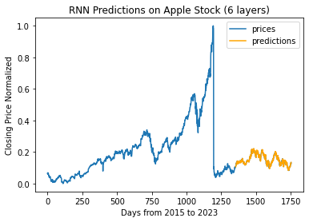

```python
visualize_predictions(rnn_model, historical_array, test_dataset, DEVICE, title='RNN Predictions on Apple Stock (6 layers)')
```

```
              precision    recall  f1-score   support

           0       0.74      0.07      0.13       195
           1       0.52      0.98      0.68       204

    accuracy                           0.53       399
   macro avg       0.63      0.52      0.41       399
weighted avg       0.63      0.53      0.41       399
```

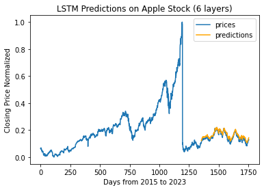

```python
visualize_predictions(lstm_model, historical_array, test_dataset, DEVICE, title='LSTM Predictions on Apple Stock (6 layers)')
```

```
              precision    recall  f1-score   support

           0       0.33      0.01      0.01       195
           1       0.51      0.99      0.67       204

    accuracy                           0.51       399
   macro avg       0.42      0.50      0.34       399
weighted avg       0.42      0.51      0.35       399
```

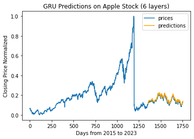

```python
visualize_predictions(gru_model, historical_array, test_dataset, DEVICE, title='GRU Predictions on Apple Stock (6 layers)')
```

### Increase Hidden Dimension

Next, we will try increasing the hidden layer of the RNN. After increasing layers didn't work this is unlikely to work but we will try it anyway.

```python
NUM_LAYERS = 2
PRED_IDX = 0
HIDDEN_SIZE = 256
```

```python
train_array, test_array = prep_RNN_data(bars_df, cols=['close'], test_pct=TEST_PCT, scaler=MinMaxScaler())
display(train_array.shape, test_array.shape)
train_dataset = RNNDataset(train_array, SEQUENCE_LENGTH,)
test_dataset = RNNDataset(test_array, SEQUENCE_LENGTH,)

display(len(train_dataset), len(test_dataset))
train_loader = torch.utils.data.DataLoader(train_dataset, BATCH_SIZE, drop_last=True, shuffle=True)
train_loader = DeviceDataLoader(train_loader, DEVICE)
test_loader = torch.utils.data.DataLoader(test_dataset, BATCH_SIZE, drop_last=True)
test_loader = DeviceDataLoader(test_loader, DEVICE)
rnn_model = RNN(input_dim=1, hidden_dim=HIDDEN_SIZE, output_dim=1, num_layers=NUM_LAYERS)
rnn_model.to(DEVICE)
lstm_model = LSTM(input_dim=1, hidden_dim=HIDDEN_SIZE, output_dim=1, num_layers=NUM_LAYERS)
lstm_model.to(DEVICE)
gru_model = GRU(input_dim=1, hidden_dim=HIDDEN_SIZE, output_dim=1, num_layers=NUM_LAYERS)
gru_model.to(DEVICE)

loss_fn = torch.nn.MSELoss()

rnn_optimizer = torch.optim.Adam(rnn_model.parameters(), lr=0.001)
lstm_optimizer = torch.optim.Adam(lstm_model.parameters(), lr=0.001)
gru_optimizer = torch.optim.Adam(gru_model.parameters(), lr=0.001)
rnn_training_losses, rnn_testing_losses = fit_model(EPOCHS, rnn_model, train_loader, test_loader, loss_fn, rnn_optimizer)
lstm_training_losses, lstm_testing_losses = fit_model(EPOCHS, lstm_model, train_loader, test_loader, loss_fn, lstm_optimizer)
gru_training_losses, gru_testing_losses = fit_model(EPOCHS, gru_model, train_loader, test_loader, loss_fn, gru_optimizer)
```

```
(1353, 1)
```

```
(451, 1)
```

```
1302
```

```
400
```

```
Epoch 0  	Train MSE: 0.01416	Test MSE: 0.00036
Epoch 10  	Train MSE: 0.00110	Test MSE: 0.00014
Epoch 20  	Train MSE: 0.00124	Test MSE: 0.00029
Epoch 30  	Train MSE: 0.00097	Test MSE: 0.00006
Epoch 40  	Train MSE: 0.00099	Test MSE: 0.00012
Epoch 50  	Train MSE: 0.00089	Test MSE: 0.00107
Epoch 60  	Train MSE: 0.00118	Test MSE: 0.00010
Epoch 70  	Train MSE: 0.00109	Test MSE: 0.00006
Epoch 80  	Train MSE: 0.03249	Test MSE: 0.01004
Epoch 90  	Train MSE: 0.02154	Test MSE: 0.00179
Epoch 0  	Train MSE: 0.02940	Test MSE: 0.00901
Epoch 10  	Train MSE: 0.00181	Test MSE: 0.00018
Epoch 20  	Train MSE: 0.00095	Test MSE: 0.00011
Epoch 30  	Train MSE: 0.00092	Test MSE: 0.00010
Epoch 40  	Train MSE: 0.00078	Test MSE: 0.00007
Epoch 50  	Train MSE: 0.00077	Test MSE: 0.00013
Epoch 60  	Train MSE: 0.00080	Test MSE: 0.00007
Epoch 70  	Train MSE: 0.00083	Test MSE: 0.00007
Epoch 80  	Train MSE: 0.00086	Test MSE: 0.00008
Epoch 90  	Train MSE: 0.00079	Test MSE: 0.00008
Epoch 0  	Train MSE: 0.01101	Test MSE: 0.00057
Epoch 10  	Train MSE: 0.00116	Test MSE: 0.00011
Epoch 20  	Train MSE: 0.00105	Test MSE: 0.00012
Epoch 30  	Train MSE: 0.00083	Test MSE: 0.00007
Epoch 40  	Train MSE: 0.00097	Test MSE: 0.00007
Epoch 50  	Train MSE: 0.00071	Test MSE: 0.00011
Epoch 60  	Train MSE: 0.00089	Test MSE: 0.00033
Epoch 70  	Train MSE: 0.00081	Test MSE: 0.00006
Epoch 80  	Train MSE: 0.00091	Test MSE: 0.00007
Epoch 90  	Train MSE: 0.00090	Test MSE: 0.00006
```

```python
historical_array = train_array[:, PRED_IDX]
historical_array.shape # get the closing prices of all the training data for context
```

```
(1353,)
```

```
              precision    recall  f1-score   support

           0       0.51      0.38      0.44       195
           1       0.52      0.65      0.58       204

    accuracy                           0.52       399
   macro avg       0.52      0.52      0.51       399
weighted avg       0.52      0.52      0.51       399
```

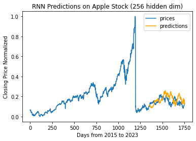

```python
visualize_predictions(rnn_model, historical_array, test_dataset, DEVICE, title='RNN Predictions on Apple Stock (256 hidden dim)')
```

```
              precision    recall  f1-score   support

           0       0.49      1.00      0.66       195
           1       0.00      0.00      0.00       204

    accuracy                           0.49       399
   macro avg       0.24      0.50      0.33       399
weighted avg       0.24      0.49      0.32       399
```

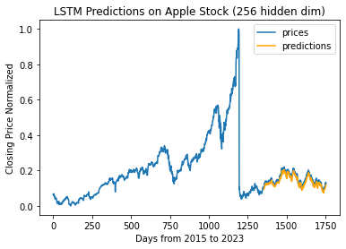

```python
visualize_predictions(lstm_model, historical_array, test_dataset, DEVICE, title='LSTM Predictions on Apple Stock (256 hidden dim)')
```

```
              precision    recall  f1-score   support

           0       0.00      0.00      0.00       195
           1       0.51      1.00      0.68       204

    accuracy                           0.51       399
   macro avg       0.26      0.50      0.34       399
weighted avg       0.26      0.51      0.35       399
```

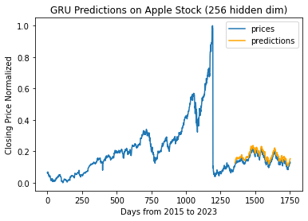

```python
visualize_predictions(gru_model, historical_array, test_dataset, DEVICE, title='GRU Predictions on Apple Stock (256 hidden dim)')
```

### Predict a different stock

For this we will choose Microsoft as another arbitrary stock to try to predict. We wil first fetch the data using the same technique as we did for Apple. Then we will again try to predict Microsoft `close` price using only `close` price.

```python
start = datetime(year=2015, month=1, day=1, hour=0, minute=0, second=0)
end = datetime(year=2023, month=2, day=1, hour=0, minute=0, second=0)
bars_df = stock_trader.get_bars('MSFT', start=start, end=end, time_resolution='day')
bars_df.reset_index(inplace=True)
bars_df.sort_values(by=['timestamp'], ascending=True, inplace=True)
print(bars_df.shape)
display(bars_df.head())
```

```
(1804, 9)
```

|  | symbol | timestamp | open | high | low | close | volume | trade_count | vwap |
| --- | --- | --- | --- | --- | --- | --- | --- | --- | --- |
| 0 | MSFT | 2015-12-01 05:00:00+00:00 | 54.41 | 55.23 | 54.30 | 55.22 | 39952779.0 | 194807.0 | 54.877235 |
| 1 | MSFT | 2015-12-02 05:00:00+00:00 | 55.32 | 55.96 | 55.06 | 55.21 | 47274879.0 | 225980.0 | 55.484361 |
| 2 | MSFT | 2015-12-03 05:00:00+00:00 | 55.49 | 55.77 | 53.93 | 54.20 | 38627835.0 | 219413.0 | 54.475820 |
| 3 | MSFT | 2015-12-04 05:00:00+00:00 | 54.12 | 56.23 | 54.10 | 55.91 | 43963662.0 | 232021.0 | 55.540921 |
| 4 | MSFT | 2015-12-07 05:00:00+00:00 | 55.79 | 55.97 | 55.29 | 55.81 | 30709765.0 | 182309.0 | 55.623798 |

```python
NUM_LAYERS = 2
PRED_IDX = 0
HIDDEN_SIZE = 100
```

```python
train_array, test_array = prep_RNN_data(bars_df, cols=['close'], test_pct=TEST_PCT, scaler=MinMaxScaler())
display(train_array.shape, test_array.shape)
train_dataset = RNNDataset(train_array, SEQUENCE_LENGTH,)
test_dataset = RNNDataset(test_array, SEQUENCE_LENGTH,)

display(len(train_dataset), len(test_dataset))
train_loader = torch.utils.data.DataLoader(train_dataset, BATCH_SIZE, drop_last=True, shuffle=True)
train_loader = DeviceDataLoader(train_loader, DEVICE)
test_loader = torch.utils.data.DataLoader(test_dataset, BATCH_SIZE, drop_last=True)
test_loader = DeviceDataLoader(test_loader, DEVICE)
rnn_model = RNN(input_dim=1, hidden_dim=HIDDEN_SIZE, output_dim=1, num_layers=NUM_LAYERS)
rnn_model.to(DEVICE)
lstm_model = LSTM(input_dim=1, hidden_dim=HIDDEN_SIZE, output_dim=1, num_layers=NUM_LAYERS)
lstm_model.to(DEVICE)
gru_model = GRU(input_dim=1, hidden_dim=HIDDEN_SIZE, output_dim=1, num_layers=NUM_LAYERS)
gru_model.to(DEVICE)

loss_fn = torch.nn.MSELoss()

rnn_optimizer = torch.optim.Adam(rnn_model.parameters(), lr=0.001)
lstm_optimizer = torch.optim.Adam(lstm_model.parameters(), lr=0.001)
gru_optimizer = torch.optim.Adam(gru_model.parameters(), lr=0.001)
rnn_training_losses, rnn_testing_losses = fit_model(EPOCHS, rnn_model, train_loader, test_loader, loss_fn, rnn_optimizer)
lstm_training_losses, lstm_testing_losses = fit_model(EPOCHS, lstm_model, train_loader, test_loader, loss_fn, lstm_optimizer)
gru_training_losses, gru_testing_losses = fit_model(EPOCHS, gru_model, train_loader, test_loader, loss_fn, gru_optimizer)
```

```
(1353, 1)
```

```
(451, 1)
```

```
1302
```

```
400
```

```
Epoch 0  	Train MSE: 0.01993	Test MSE: 0.00235
Epoch 10  	Train MSE: 0.00021	Test MSE: 0.00067
Epoch 20  	Train MSE: 0.00015	Test MSE: 0.00117
Epoch 30  	Train MSE: 0.00015	Test MSE: 0.00049
Epoch 40  	Train MSE: 0.00016	Test MSE: 0.00047
Epoch 50  	Train MSE: 0.00013	Test MSE: 0.00046
Epoch 60  	Train MSE: 0.00016	Test MSE: 0.00039
Epoch 70  	Train MSE: 0.00014	Test MSE: 0.00037
Epoch 80  	Train MSE: 0.00013	Test MSE: 0.00106
Epoch 90  	Train MSE: 0.00014	Test MSE: 0.00059
Epoch 0  	Train MSE: 0.03058	Test MSE: 0.03505
Epoch 10  	Train MSE: 0.00026	Test MSE: 0.00136
Epoch 20  	Train MSE: 0.00023	Test MSE: 0.00121
Epoch 30  	Train MSE: 0.00023	Test MSE: 0.00135
Epoch 40  	Train MSE: 0.00021	Test MSE: 0.00079
Epoch 50  	Train MSE: 0.00018	Test MSE: 0.00086
Epoch 60  	Train MSE: 0.00017	Test MSE: 0.00071
Epoch 70  	Train MSE: 0.00018	Test MSE: 0.00078
Epoch 80  	Train MSE: 0.00013	Test MSE: 0.00056
Epoch 90  	Train MSE: 0.00012	Test MSE: 0.00049
Epoch 0  	Train MSE: 0.02657	Test MSE: 0.01894
Epoch 10  	Train MSE: 0.00013	Test MSE: 0.00093
Epoch 20  	Train MSE: 0.00012	Test MSE: 0.00041
Epoch 30  	Train MSE: 0.00016	Test MSE: 0.00049
Epoch 40  	Train MSE: 0.00016	Test MSE: 0.00038
Epoch 50  	Train MSE: 0.00015	Test MSE: 0.00052
Epoch 60  	Train MSE: 0.00016	Test MSE: 0.00035
Epoch 70  	Train MSE: 0.00011	Test MSE: 0.00041
Epoch 80  	Train MSE: 0.00012	Test MSE: 0.00048
Epoch 90  	Train MSE: 0.00013	Test MSE: 0.00034
```

```python
historical_array = train_array[:, PRED_IDX]
historical_array.shape # get the closing prices of all the training data for context
```

```
(1353,)
```

```
              precision    recall  f1-score   support

           0       0.52      0.52      0.52       206
           1       0.48      0.48      0.48       193

    accuracy                           0.50       399
   macro avg       0.50      0.50      0.50       399
weighted avg       0.50      0.50      0.50       399
```

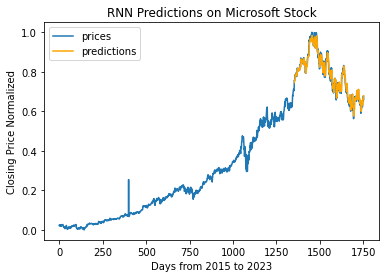

```python
visualize_predictions(rnn_model, historical_array, test_dataset, DEVICE, title='RNN Predictions on Microsoft Stock')
```

```
              precision    recall  f1-score   support

           0       0.51      0.86      0.64       206
           1       0.46      0.12      0.20       193

    accuracy                           0.51       399
   macro avg       0.49      0.49      0.42       399
weighted avg       0.49      0.51      0.43       399
```

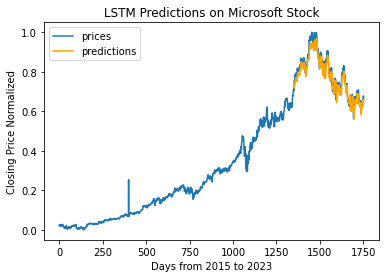

```python
visualize_predictions(lstm_model, historical_array, test_dataset, DEVICE, title='LSTM Predictions on Microsoft Stock')
```

```
              precision    recall  f1-score   support

           0       0.52      0.65      0.57       206
           1       0.48      0.35      0.41       193

    accuracy                           0.50       399
   macro avg       0.50      0.50      0.49       399
weighted avg       0.50      0.50      0.49       399
```

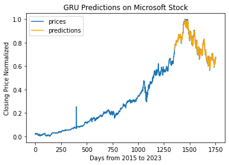

```python
visualize_predictions(gru_model, historical_array, test_dataset, DEVICE, title='GRU Predictions on Microsoft Stock')
```

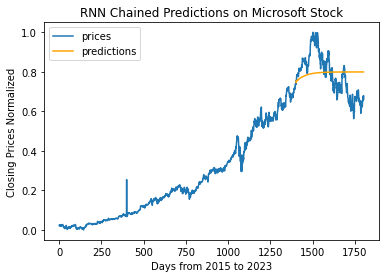

```python
visualize_chained_predictions(rnn_model, train_array, test_array, DEVICE, title='RNN Chained Predictions on Microsoft Stock')
```

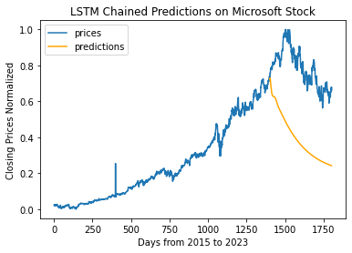

```python
visualize_chained_predictions(lstm_model, train_array, test_array, DEVICE, title='LSTM Chained Predictions on Microsoft Stock')
```

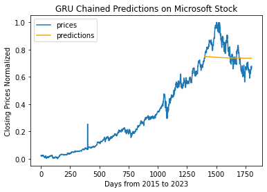

```python
visualize_chained_predictions(gru_model, train_array, test_array, DEVICE, title='GRU Chained Predictions on Microsoft Stock')
```

# Conclusion

At a high level we cannot predict stock price using only historical stock data. The accuracy shows us that the model is only guessing which direction the market will actually move. The chained predictions show us how far we are from a truly good model. However, by using the prediction plot, you may be able to fool someone into thinking that you can actually predict stock price.